# Latihan Pertemuan 4

## Library

```r
library(forecast)
library(TSA)
library(tseries)
```

# MA(2)

## MA(2) Manual

```r
set.seed(1234)
n  <- 300
wn <- rnorm(n)

ma2_manual <- rep(0, n)
ma2_manual[1] <- wn[1]                        # Y1 = e1
ma2_manual[2] <- wn[2] + 0.4*wn[1]            # Y2 = e2 + 0.4 e1

for(i in 3:n){
  ma2_manual[i] <- wn[i] + 0.4*wn[i-1] + 0.6*wn[i-2]
}

ma2_manual
```

```
##   [1] -1.207065749 -0.205397058  0.471173424 -1.745463687  0.141510314
##   [6] -0.729712854 -0.114842790 -0.472894305 -1.127948717 -1.443797742
##  [11] -1.171879031 -1.723286222 -1.461924092 -0.845074607  0.519525249
##  [16]  0.312187420  0.020572732 -1.181770516 -1.508255550  1.534249256
##  [21]  0.598119283  1.012450498 -0.556369299 -0.011041246 -0.774213194
##  [26] -1.449939345 -0.420758391 -1.662676381 -0.079747157 -1.556197355
##  [31]  0.718835126 -0.596243221 -0.238298741 -1.070389923 -2.255260716
##  [36] -2.120011486 -3.624543435 -2.913580609 -2.138714925 -1.388210999
##  [41]  1.086560934 -0.768382742 -0.413123964 -1.263954490 -1.619808057
##  [46] -1.534624150 -2.091327966 -2.276021753 -1.689013389 -1.457572736
##  [51] -2.319068111 -1.602598402 -2.425338748 -1.807763414 -1.233628102
##  [56] -0.110845196  1.775654086  0.223607057  2.285258743 -0.979456751
##  [61]  1.157010823  2.116941328  1.378789117  0.845856907 -0.296314421
##  [66]  1.372262398 -0.432336811  1.978634754  1.193531021  1.688995021
##  [71]  0.939220832 -0.250827924 -0.544575725  0.228395751  2.109671129
```

[output cut: 45 more lines]

## MA(2) arima.sim

```r
theta <- c(0.4, 0.6)
ma <- arima.sim(model = list(ma = theta), n = n)
```

## Plot Time Series

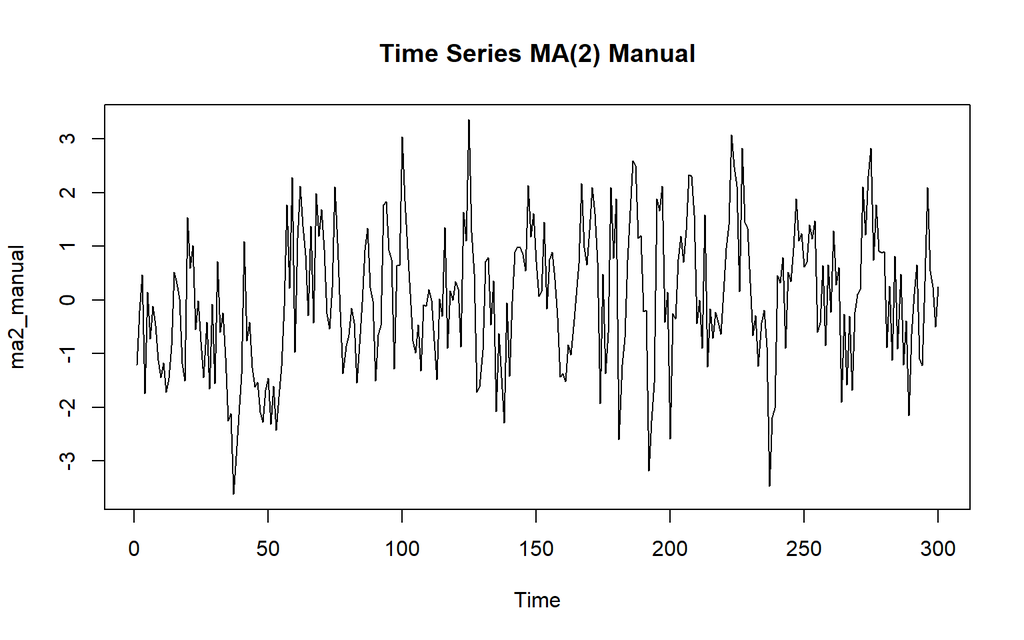

```r
ts.plot(ma2_manual, main = "Time Series MA(2) Manual")
```

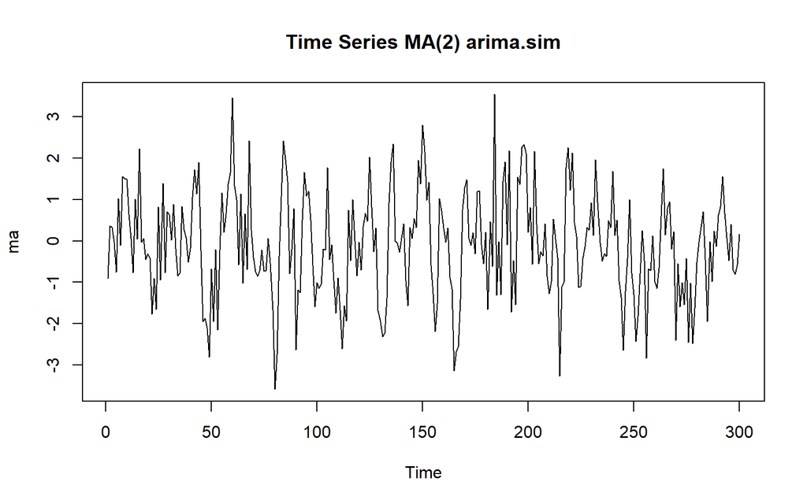

```r
ts.plot(ma, main = "Time Series MA(2) arima.sim")
```

## Plot ACF, PACF, EACF

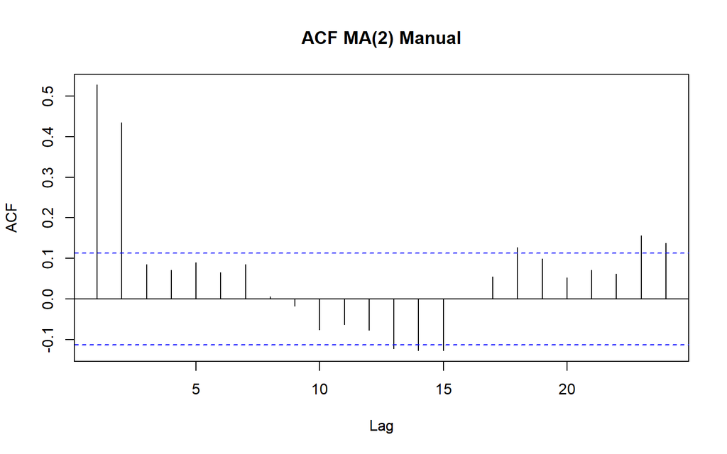

```r
acf(ma2_manual, main = "ACF MA(2) Manual")
```

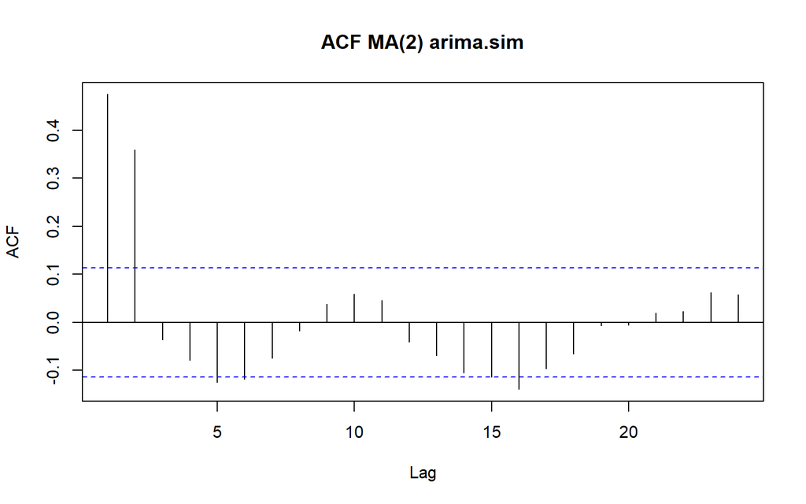

```r
acf(ma, main = "ACF MA(2) arima.sim")
```

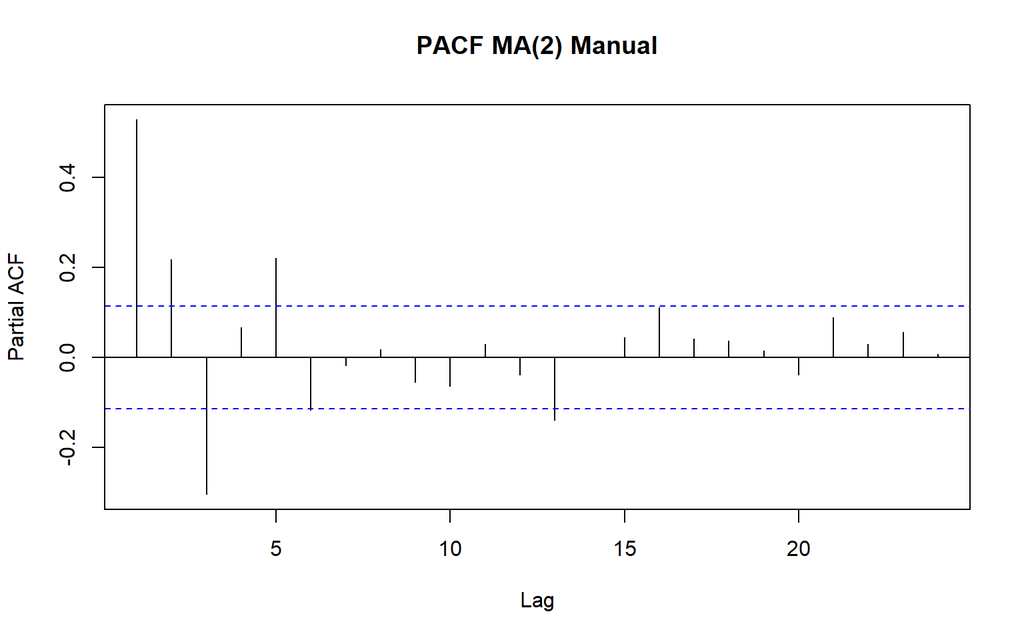

```r
pacf(ma2_manual, main = "PACF MA(2) Manual")
```

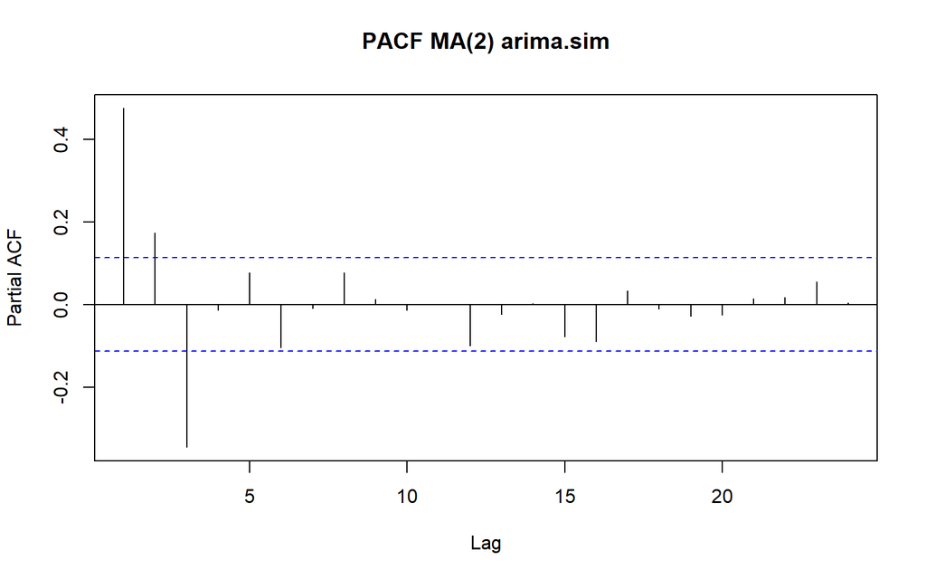

```r
pacf(ma, main = "PACF MA(2) arima.sim")
```

```r
TSA::eacf(ma2_manual)
```

```
## AR/MA
##   0 1 2 3 4 5 6 7 8 9 10 11 12 13
## 0 x x o o o o o o o o o  o  x  x
## 1 x x x o o o o o o o o  o  o  o
## 2 x x x x o o o o o o o  o  o  o
## 3 x x x x x o o o o o o  o  o  o
## 4 x x x x x o o o o o o  o  o  o
## 5 x x o x x o x o o o o  o  o  o
## 6 x x x o x o o x o o o  o  o  o
## 7 x o x o x o o x o o o  o  o  o
```

```r
TSA::eacf(ma)
```

```
## AR/MA
##   0 1 2 3 4 5 6 7 8 9 10 11 12 13
## 0 x x o o x x o o o o o  o  o  o
## 1 x x x o o o o o o o o  o  o  o
## 2 x x x o o o o o o o o  o  o  o
## 3 o x x x o o o o o o o  o  o  o
## 4 x o x x x o o o o o o  o  o  o
## 5 x x x x x x o o o o o  o  o  o
## 6 o x x x o o o o o o o  o  o  o
## 7 x x x x o o o o o o o  o  o  o
```

## Scatterplot

### Korelasi antara $Y_t$ dengan $Y_{t-1}$ Manual

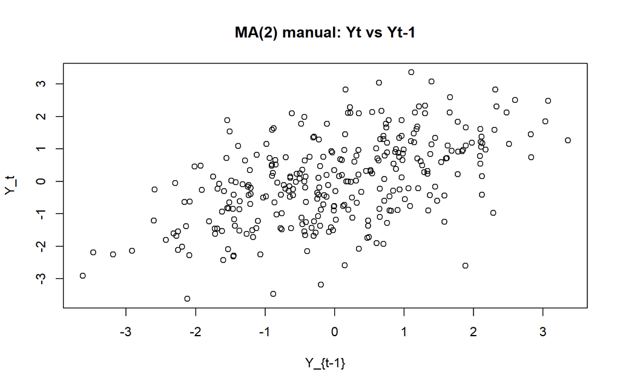

```r
yt_ma_manual   <- ma2_manual[-1]
yt_1_ma_manual <- ma2_manual[-length(ma2_manual)]
plot(y = yt_ma_manual, x = yt_1_ma_manual,
     main = "MA(2) manual: Yt vs Yt-1", xlab = "Y_{t-1}", ylab = "Y_t")
```

```r
cor(yt_ma_manual, yt_1_ma_manual)
```

```
## [1] 0.5282201
```

### Korelasi antara $Y_t$ dengan $Y_{t-2}$ Manual

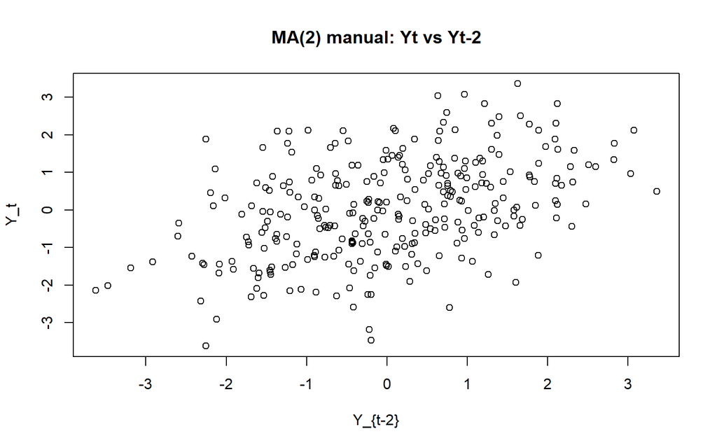

```r
yt_ma2_manual  <- ma2_manual[-c(1,2)]
yt_2_ma_manual <- ma2_manual[-c((length(ma2_manual)-1), length(ma2_manual))]
plot(y = yt_ma2_manual, x = yt_2_ma_manual,
     main = "MA(2) manual: Yt vs Yt-2", xlab = "Y_{t-2}", ylab = "Y_t")
```

```r
cor(yt_ma2_manual, yt_2_ma_manual)
```

```
## [1] 0.4356204
```

### Korelasi antara $Y_t$ dengan $Y_{t-3}$ Manual

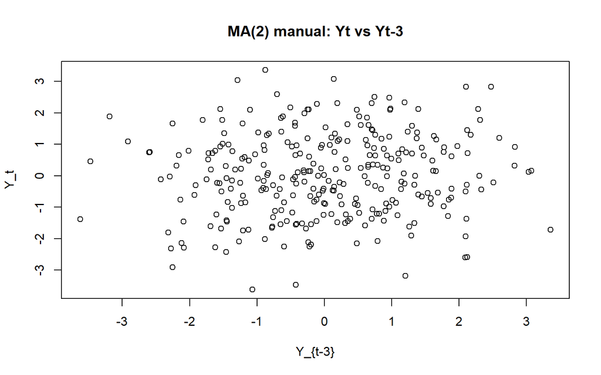

```r
yt_ma3_manual  <- ma2_manual[-c(1,2,3)]
yt_3_ma_manual <- ma2_manual[-c((length(ma2_manual)-2):length(ma2_manual))]
plot(y = yt_ma3_manual, x = yt_3_ma_manual,
     main = "MA(2) manual: Yt vs Yt-3", xlab = "Y_{t-3}", ylab = "Y_t")
```

```r
cor(yt_ma3_manual, yt_3_ma_manual)
```

```
## [1] 0.08544546
```

### Korelasi antara $Y_t$ dengan $Y_{t-1}$ arima.sim

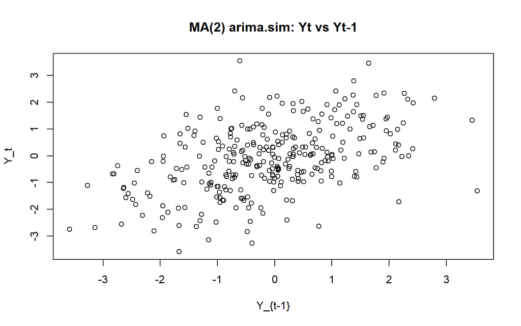

```r
yt_ma   <- ma[-1]                 # Y_t
yt_1_ma <- ma[-length(ma)]        # Y_{t-1}
plot(y = yt_ma, x = yt_1_ma,
     main = "MA(2) arima.sim: Yt vs Yt-1", xlab = "Y_{t-1}", ylab = "Y_t")
```

```r
cor(yt_ma, yt_1_ma)
```

```
## [1] 0.4750929
```

### Korelasi antara $Y_t$ dengan $Y_{t-2}$ arima.sim

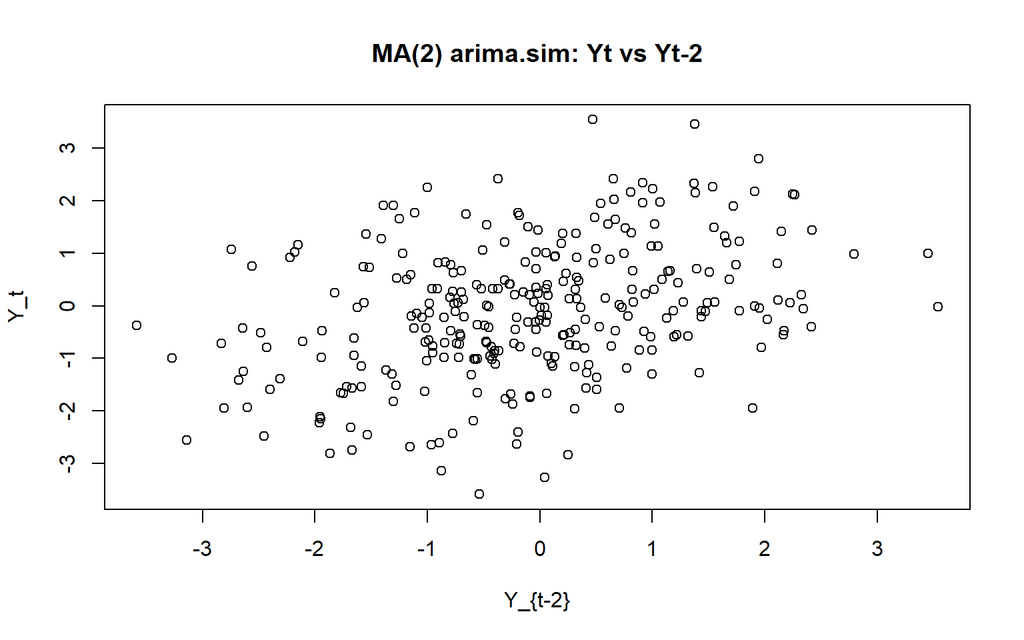

```r
yt_ma2  <- ma[-c(1,2)]                              # Y_t
yt_2_ma <- ma[-c((length(ma)-1), length(ma))]       # Y_{t-2}
plot(y = yt_ma2, x = yt_2_ma,
     main = "MA(2) arima.sim: Yt vs Yt-2", xlab = "Y_{t-2}", ylab = "Y_t")
```

```r
cor(yt_ma2, yt_2_ma)
```

```
## [1] 0.3599318
```

### Korelasi antara $Y_t$ dengan $Y_{t-3}$ arima.sim

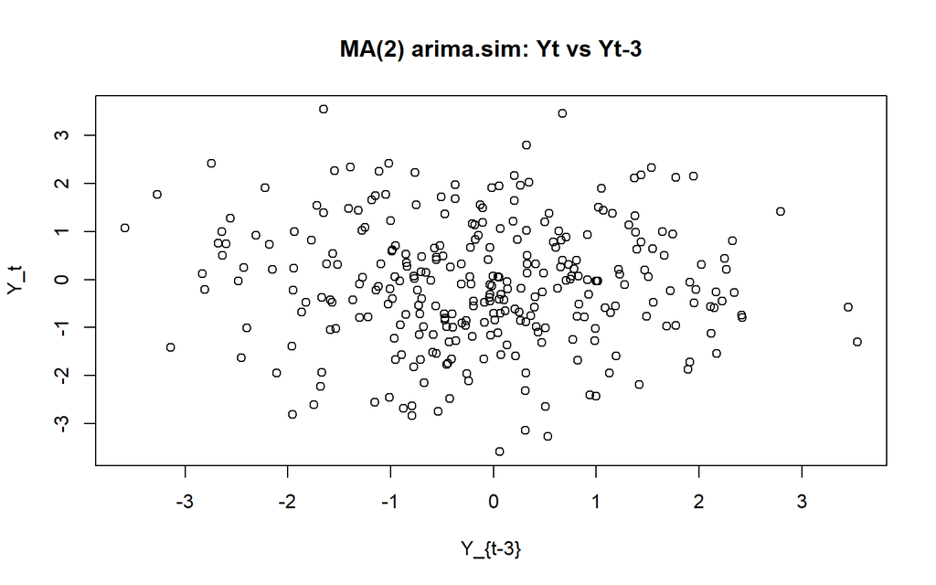

```r
yt_ma3  <- ma[-c(1,2,3)]                            # Y_t
yt_3_ma <- ma[-c((length(ma)-2):length(ma))]        # Y_{t-3}
plot(y = yt_ma3, x = yt_3_ma,
     main = "MA(2) arima.sim: Yt vs Yt-3", xlab = "Y_{t-3}", ylab = "Y_t")
```

```r
cor(yt_ma3, yt_3_ma)
```

```
## [1] -0.03614967
```

## Autokorelasi

```r
theta <- c(0.4, 0.6)
acf_theory_ma2 <- ARMAacf(ma = theta, lag.max = 10)
acf_theory_ma2
```

```
##         0         1         2         3         4         5         6         7
## 1.0000000 0.4210526 0.3947368 0.0000000 0.0000000 0.0000000 0.0000000 0.0000000
##         8         9        10
## 0.0000000 0.0000000 0.0000000
```

```r
acf_theory_ma2[-1]
```

```
##         1         2         3         4         5         6         7         8
## 0.4210526 0.3947368 0.0000000 0.0000000 0.0000000 0.0000000 0.0000000 0.0000000
##         9        10
## 0.0000000 0.0000000
```

```r
# manual
acf(ma2_manual, lag.max = 10, plot = FALSE)$acf
```

```
## , , 1
##
##               [,1]
##  [1,]  0.527403800
##  [2,]  0.434811378
##  [3,]  0.085266051
##  [4,]  0.071480314
##  [5,]  0.089653347
##  [6,]  0.065180718
##  [7,]  0.084758297
##  [8,]  0.005668758
##  [9,] -0.017171527
## [10,] -0.075594452
```

```r
# arima.sim
acf(ma,   lag.max = 10, plot = FALSE)$acf
```

```
## , , 1
##
##              [,1]
##  [1,]  0.47473144
##  [2,]  0.35949296
##  [3,] -0.03608089
##  [4,] -0.07858146
##  [5,] -0.12418465
##  [6,] -0.11834565
##  [7,] -0.07421307
##  [8,] -0.01706904
##  [9,]  0.03801561
## [10,]  0.05844698
```

## Penjelasan

1. Stasioneritas

Semua proses MA(q) stasioner (mean & kovarians konstan).

2.Bentuk ACF/PACF/EACF

ACF: “cut-off” di lag 2 (ρₖ≈0 untuk k>2).

PACF: tailing off (memudar perlahan).

3. Scatterplot Yt vs lag

Terlihat hubungan pada lag 1 & 2; nyaris hilang mulai lag 3.

4. Autokorelasi teoritis vs manual

Manual vs arima.sim (sampel ACF): keduanya mendekati nilai teoritis di lag 1–2; untuk k>2 nilai sampel berfluktuasi kecil di sekitar 0 (efek sampel terbatas). Perbedaan kecil antar “manual” dan “sim” murni karena realisasi noise acak yang berbeda.

# AR(2)

## AR(2) Manual

```r
set.seed(1234)
n <- 300
wn_ar <- rnorm(n)

ar2_manual <- rep(0, n)
ar2_manual[1:2] <- 0
for(i in 3:n){
  ar2_manual[i] <- 0.5*ar2_manual[i-1] + 0.2*ar2_manual[i-2] + wn_ar[i]
}
ar2_manual
```

```
##   [1]  0.000000000  0.000000000  1.084441177 -1.803477114 -0.255725633
##   [6]  0.017497653 -0.617136260 -0.851700455 -1.113729479 -1.617242660
##  [11] -1.508559925 -2.076114939 -2.116023349 -1.408775845 -0.168098534
##  [16] -0.476089930 -0.782674178 -1.397750491 -1.692581762  1.289994199
##  [21]  0.440568968 -0.012402573 -0.358635365  0.277791244 -0.626551698
##  [26] -1.705922511 -0.403515874 -1.566598162 -0.879140556 -1.688838512
##  [31]  0.082050179 -0.772335692 -1.079197848 -1.195324123 -2.442595100
##  [36] -2.627981637 -3.982549487 -3.857864263 -3.019735888 -2.747338337
##  [41] -0.528120081 -1.882170431 -1.902073866 -1.608094021 -2.178801860
##  [46] -2.379534052 -2.732845591 -3.094315491 -2.617554983 -2.424490547
##  [51] -3.541787527 -2.837867797 -3.236181029 -3.200626083 -2.409858771
##  [56] -1.281998783  0.524846327 -0.767330017  1.327213886 -0.647667608
##  [61]  0.598197437  2.718556268  1.444157232  0.596156290  0.579304835
##  [66]  2.185968124  0.070237292  1.840139450  2.263681974  1.836341674
##  [71]  1.377800071  0.600699632  0.209385897  0.873119443  2.548707762
```

[output cut: 45 more lines]

## AR(2) arima.sim

```r
phi <- c(0.5, 0.2)
ar <- arima.sim(model = list(ar = phi), n = n)
```

## Plot Time Series

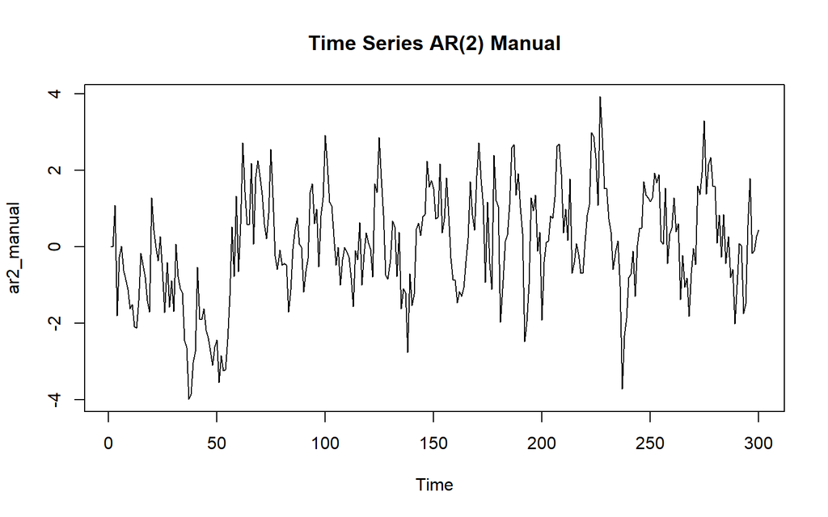

```r
ts.plot(ar2_manual, main = "Time Series AR(2) Manual")
```

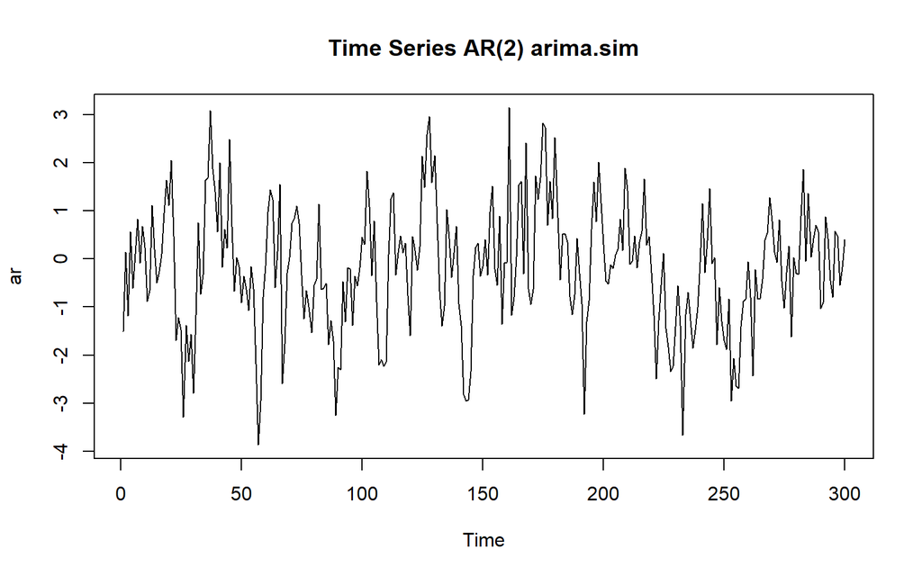

```r
ts.plot(ar, main = "Time Series AR(2) arima.sim")
```

## Plot ACF, PACF, EACF

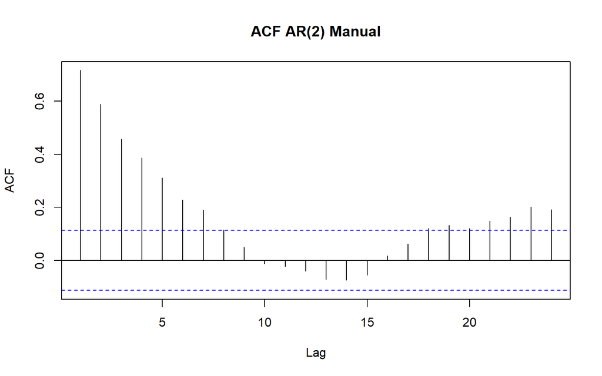

```r
acf(ar2_manual, main = "ACF AR(2) Manual")
```

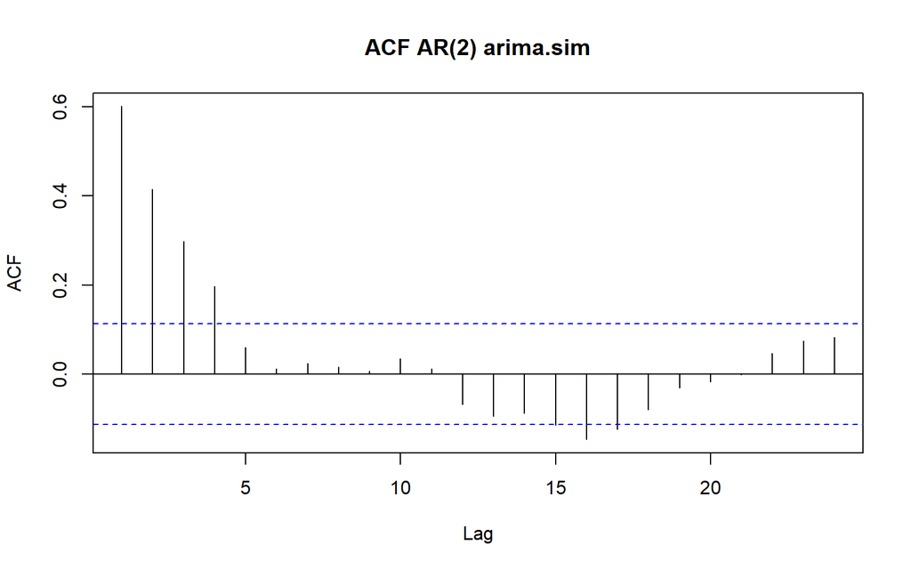

```r
acf(ar, main = "ACF AR(2) arima.sim")
```

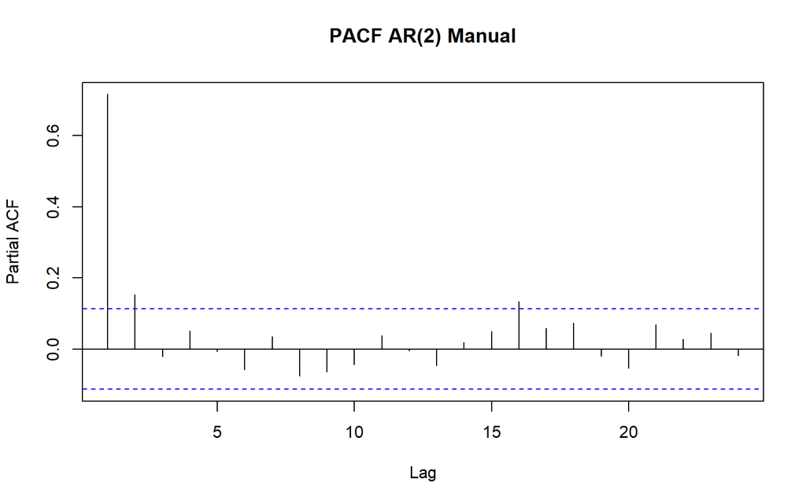

```r
pacf(ar2_manual, main = "PACF AR(2) Manual")
```

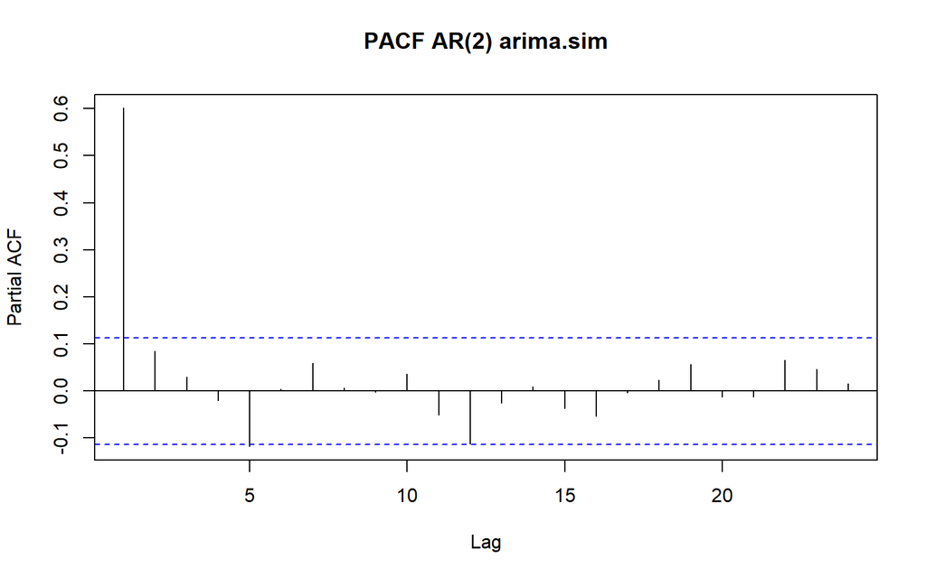

```r
pacf(ar, main = "PACF AR(2) arima.sim")
```

```r
TSA::eacf(ar2_manual)
```

```
## AR/MA
##   0 1 2 3 4 5 6 7 8 9 10 11 12 13
## 0 x x x x x x x o o o o  o  o  o
## 1 x o o o o o o o o o o  o  o  o
## 2 x o o o o o o o o o o  o  o  o
## 3 x x o o o o o o o o o  o  o  o
## 4 o x o o o o o o o o o  o  o  o
## 5 o x o x o o x o o o o  o  o  o
## 6 x x x x o o o o o o o  o  o  o
## 7 x x x o x x o o o o o  o  o  o
```

```r
TSA::eacf(ar)
```

```
## AR/MA
##   0 1 2 3 4 5 6 7 8 9 10 11 12 13
## 0 x x x x o o o o o o o  o  o  o
## 1 x o o x o o o o o o o  o  o  o
## 2 x o o x o o o o o o o  o  o  o
## 3 x x o o o o o o o o o  o  o  o
## 4 x x x x o o o o o o o  o  o  o
## 5 o x o x o o o o o o o  o  o  o
## 6 o x x o x o o o o o o  o  o  o
## 7 x o o o x x o o o o o  o  o  o
```

## Scatterplot

### Korelasi antara $Y_t$ dengan $Y_{t-1}$ Manual

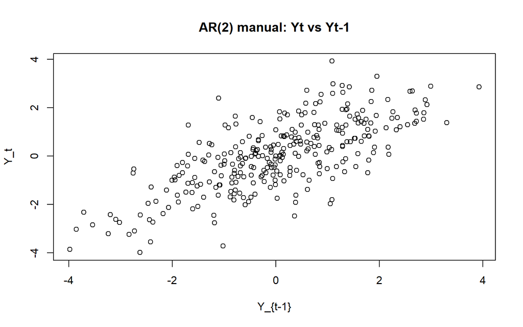

```r
yt_ar_manual   <- ar2_manual[-1]
yt_1_ar_manual <- ar2_manual[-length(ar2_manual)]
plot(y = yt_ar_manual, x = yt_1_ar_manual,
     main = "AR(2) manual: Yt vs Yt-1", xlab = "Y_{t-1}", ylab = "Y_t")
```

```r
cor(yt_ar_manual, yt_1_ar_manual)
```

```
## [1] 0.7169294
```

### Korelasi antara $Y_t$ dengan $Y_{t-2}$ Manual

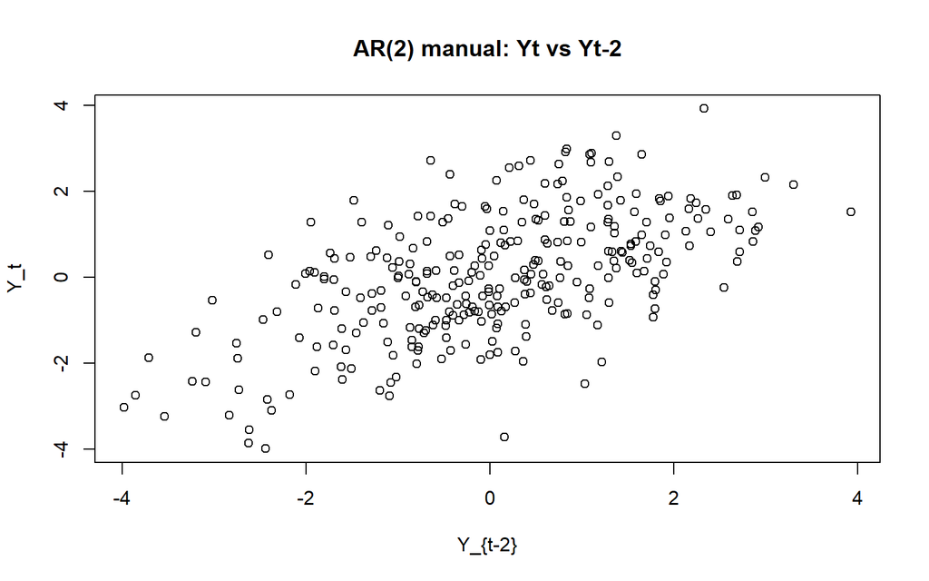

```r
yt_ar2_manual  <- ar2_manual[-c(1,2)]
yt_2_ar_manual <- ar2_manual[-c((length(ar2_manual)-1), length(ar2_manual))]
plot(y = yt_ar2_manual, x = yt_2_ar_manual,
     main = "AR(2) manual: Yt vs Yt-2", xlab = "Y_{t-2}", ylab = "Y_t")
```

```r
cor(yt_ar2_manual, yt_2_ar_manual)
```

```
## [1] 0.5886974
```

### Korelasi antara $Y_t$ dengan $Y_{t-3}$ Manual

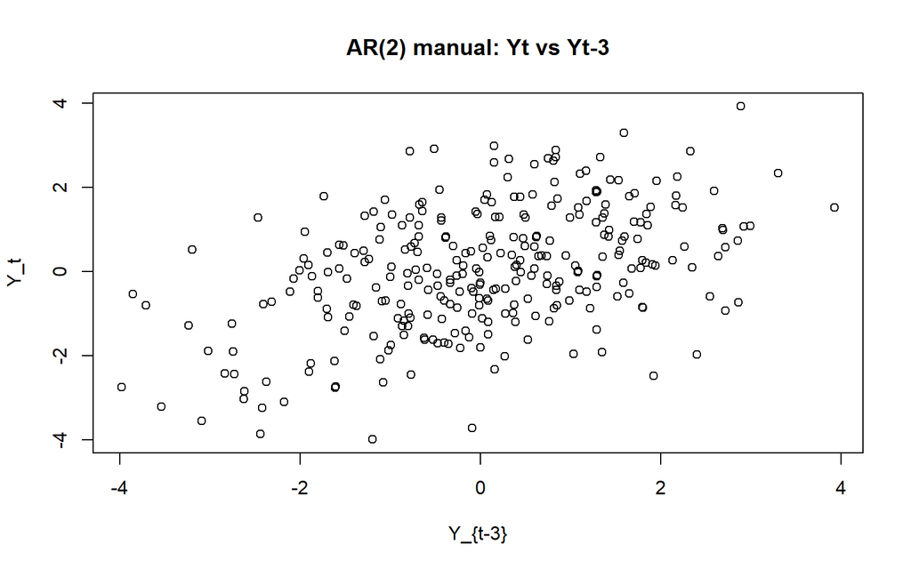

```r
yt_ar3_manual  <- ar2_manual[-c(1,2,3)]
yt_3_ar_manual <- ar2_manual[-c((length(ar2_manual)-2):length(ar2_manual))]
plot(y = yt_ar3_manual, x = yt_3_ar_manual,
     main = "AR(2) manual: Yt vs Yt-3", xlab = "Y_{t-3}", ylab = "Y_t")
```

```r
cor(yt_ar3_manual, yt_3_ar_manual)
```

```
## [1] 0.4579354
```

### Korelasi antara $Y_t$ dengan $Y_{t-1}$ arima.sim

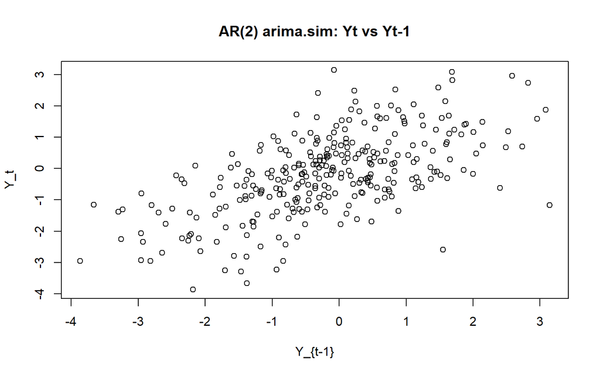

```r
yt_ar   <- ar[-1]
yt_1_ar <- ar[-length(ar)]
plot(y = yt_ar, x = yt_1_ar,
     main = "AR(2) arima.sim: Yt vs Yt-1", xlab = "Y_{t-1}", ylab = "Y_t")
```

```r
cor(yt_ar, yt_1_ar)
```

```
## [1] 0.6022804
```

### Korelasi antara $Y_t$ dengan $Y_{t-2}$ arima.sim

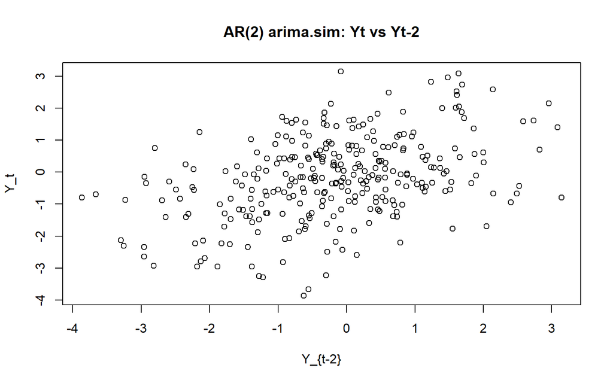

```r
yt_ar2  <- ar[-c(1,2)]
yt_2_ar <- ar[-c((length(ar)-1), length(ar))]
plot(y = yt_ar2, x = yt_2_ar,
     main = "AR(2) arima.sim: Yt vs Yt-2", xlab = "Y_{t-2}", ylab = "Y_t")
```

```r
cor(yt_ar2, yt_2_ar)
```

```
## [1] 0.416304
```

### Korelasi antara $Y_t$ dengan $Y_{t-3}$ arima.sim

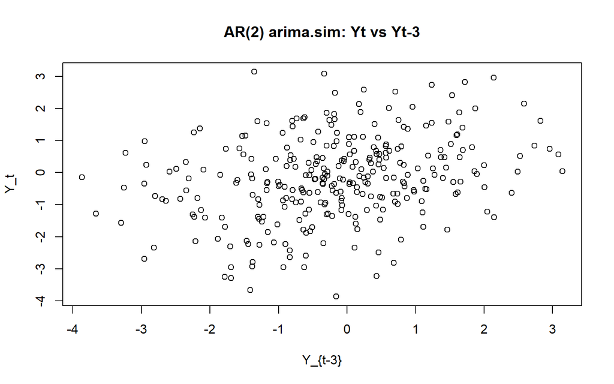

```r
yt_ar3  <- ar[-c(1,2,3)]
yt_3_ar <- ar[-c((length(ar)-2):length(ar))]
plot(y = yt_ar3, x = yt_3_ar,
     main = "AR(2) arima.sim: Yt vs Yt-3", xlab = "Y_{t-3}", ylab = "Y_t")
```

```r
cor(yt_ar3, yt_3_ar)
```

```
## [1] 0.2996039
```

## Autokorelasi

```r
# Teoritis
acf_theory_ar2 <- ARMAacf(ar = phi, lag.max = 10)
acf_theory_ar2
```

```
##          0          1          2          3          4          5          6
## 1.00000000 0.62500000 0.51250000 0.38125000 0.29312500 0.22281250 0.17003125
##          7          8          9         10
## 0.12957812 0.09879531 0.07531328 0.05741570
```

```r
acf_theory_ar2[-1]  # lag 1..10
```

```
##          1          2          3          4          5          6          7
## 0.62500000 0.51250000 0.38125000 0.29312500 0.22281250 0.17003125 0.12957812
##          8          9         10
## 0.09879531 0.07531328 0.05741570
```

```r
# Sampel
acf(ar2_manual, lag.max = 10, plot = FALSE)$acf
```

```
## , , 1
##
##              [,1]
##  [1,]  0.71684010
##  [2,]  0.58859800
##  [3,]  0.45745972
##  [4,]  0.38622215
##  [5,]  0.31122917
##  [6,]  0.22826172
##  [7,]  0.19033221
##  [8,]  0.11442678
##  [9,]  0.04933291
## [10,] -0.01234642
```

```r
acf(ar,        lag.max = 10, plot = FALSE)$acf
```

```
## , , 1
##
##              [,1]
##  [1,] 0.601007134
##  [2,] 0.415378655
##  [3,] 0.298599079
##  [4,] 0.197404616
##  [5,] 0.059608267
##  [6,] 0.012341537
##  [7,] 0.023914100
##  [8,] 0.016421253
##  [9,] 0.006715185
## [10,] 0.034950870
```

## Penjelasan

1. Stasioneritas

Untuk φ=(0.5,0.2), |z|≈1.312 dan 3.812

2.Bentuk ACF/PACF/EACF

ACF: tailing off (peluruhan halus mengarah ke nol).

EACF: baris p≈2 bersih.

3. Scatterplot Yt vs lag

Korelasi paling kuat di lag 1 & 2, melemah sesudahnya.

# ARMA(2,2)

## ARMA(2,2) Manual

```r
set.seed(1234)
n <- 300
wn_arma <- rnorm(n)

arma22_manual <- rep(0, n)
arma22_manual[1] <- wn_arma[1]
arma22_manual[2] <- 0.5*arma22_manual[1] + wn_arma[2] + 0.4*wn_arma[1]
for(i in 3:n){
  arma22_manual[i] <- 0.5*arma22_manual[i-1] + 0.2*arma22_manual[i-2] +
                      wn_arma[i] + 0.4*wn_arma[i-1] + 0.6*wn_arma[i-2]
}
arma22_manual
```

```
##   [1] -1.20706575 -0.80892993 -0.17470469 -1.99460202 -0.89073163 -1.57399907
##   [7] -1.07998865 -1.32768845 -2.00779067 -2.71323077 -2.93005255 -3.73095865
##  [13] -3.91341393 -3.54797330 -2.03714419 -1.41597933 -1.09484577 -2.01238927
##  [19] -2.73341934 -0.23493827 -0.06603372  0.93244599 -0.10335305  0.12377143
##  [25] -0.73299809 -1.79168410 -1.46320006 -2.75261323 -1.74869379 -2.98106689
##  [31] -1.12143708 -1.75317514 -1.33917373 -2.09061181 -3.56840137 -4.32233453
##  [37] -6.49939098 -7.02774300 -6.95246462 -6.26999191 -3.43892795 -3.74184510
##  [43] -2.97183210 -3.49823956 -3.96329426 -4.21591919 -4.99194641 -5.61517880
##  [49] -5.49499207 -5.32810453 -6.08211879 -5.70927870 -6.49640186 -6.19782008
##  [55] -5.63181852 -4.16631847 -1.43386885 -1.32659106  1.33518944 -0.57718024
##  [61]  1.13545859  2.56923457  2.89049812  2.80495288  1.68426164  2.77538380
##  [67]  1.29220742  3.17981522  3.04188011  3.84589812  3.47054592  2.25362466
##  [73]  1.27634579  1.31729358  3.02358707  2.83893413  1.81428668  0.10302896
##  [79] -0.45121970 -0.85290753 -0.66635425 -0.93510416 -2.14779642 -2.08562341
##  [85] -1.51503473 -0.24121274  0.91556687  0.64537308  0.48311177 -1.14217407
```

[output cut: 35 more lines]

## ARMA(2,2) arima.sim

```r
phi   <- c(0.5, 0.2)
theta <- c(0.4, 0.6)
arma  <- arima.sim(model = list(ar = phi, ma = theta), n = n)
```

## Plot Time Series

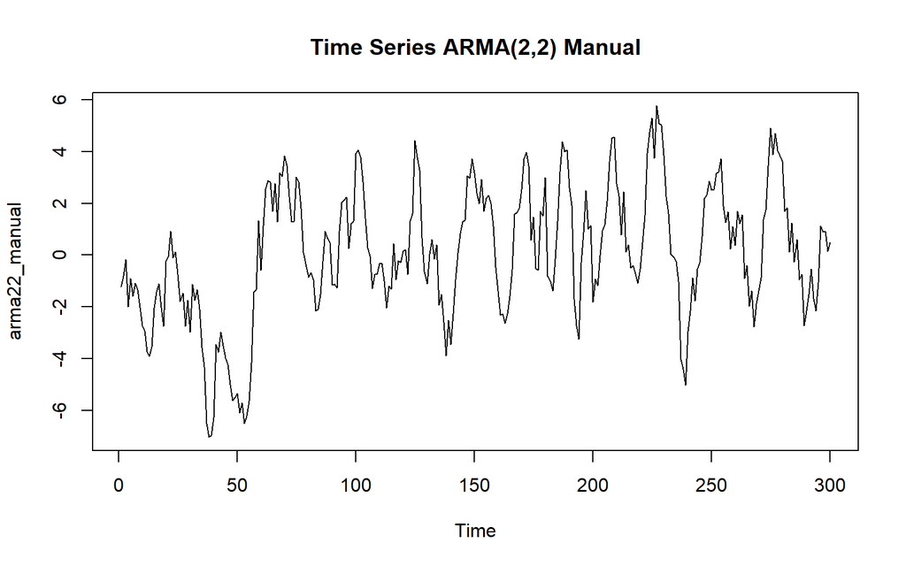

```r
ts.plot(arma22_manual, main = "Time Series ARMA(2,2) Manual")
```

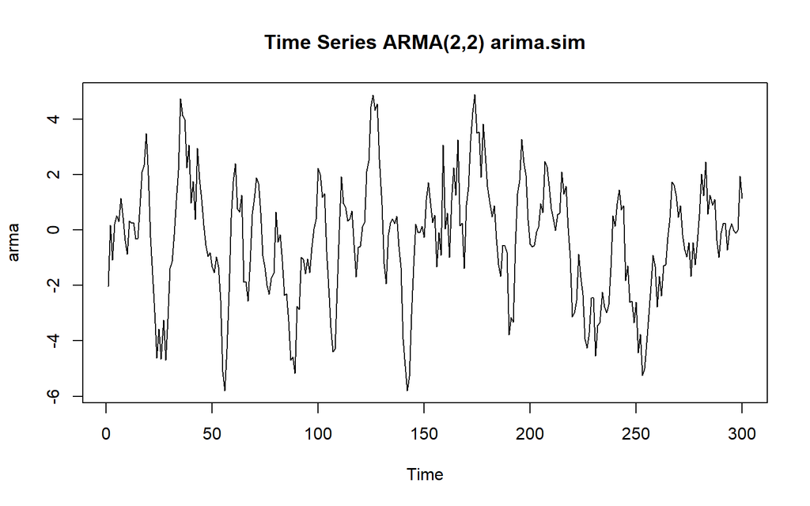

```r
ts.plot(arma, main = "Time Series ARMA(2,2) arima.sim")
```

## Plot ACF, PACF, EACF

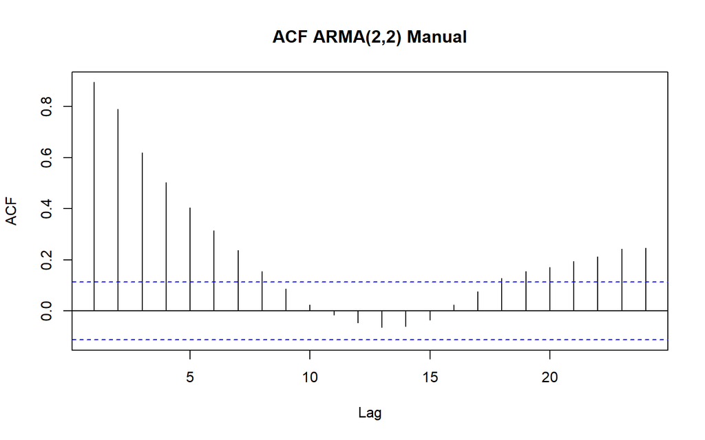

```r
acf(arma22_manual, main = "ACF ARMA(2,2) Manual")
```

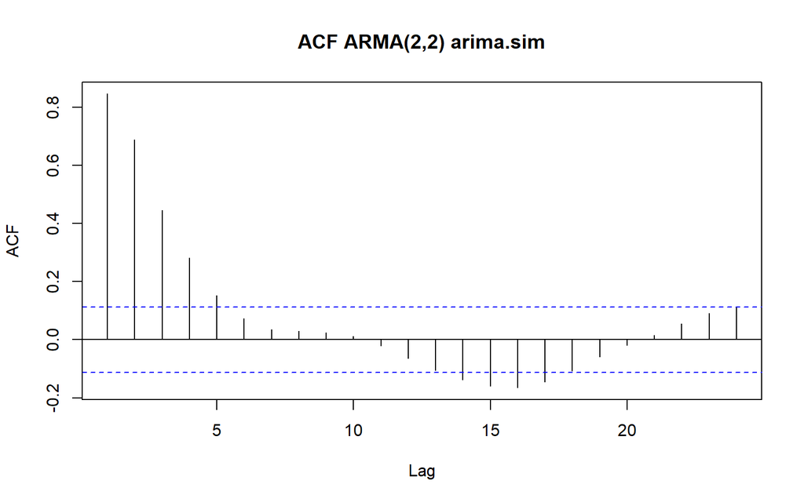

```r
acf(arma,           main = "ACF ARMA(2,2) arima.sim")
```

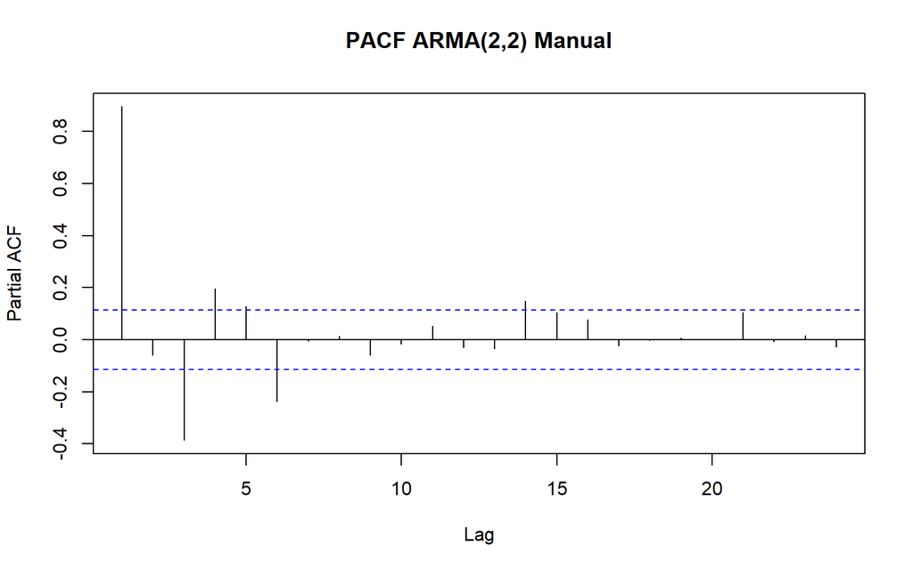

```r
pacf(arma22_manual, main = "PACF ARMA(2,2) Manual")
```

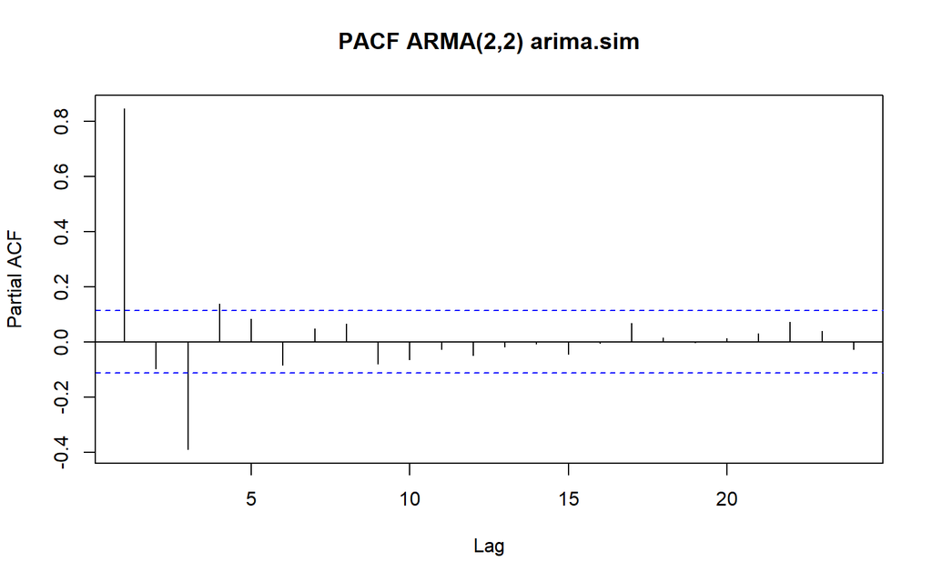

```r
pacf(arma,           main = "PACF ARMA(2,2) arima.sim")
```

```r
TSA::eacf(arma22_manual)
```

```
## AR/MA
##   0 1 2 3 4 5 6 7 8 9 10 11 12 13
## 0 x x x x x x x x o o o  o  o  o
## 1 o x o o o o x o o o o  o  o  o
## 2 x x o o o o x o o o o  o  o  o
## 3 x x o x o o x o o o o  o  o  o
## 4 x x x x o o x o o o o  o  o  o
## 5 x x x x x x x o o o o  o  o  o
## 6 o o x o x x o o o o o  o  o  o
## 7 o o x o x x o x o o o  o  o  o
```

```r
TSA::eacf(arma)
```

```
## AR/MA
##   0 1 2 3 4 5 6 7 8 9 10 11 12 13
## 0 x x x x x o o o o o o  o  o  x
## 1 x x o o o o o o o o o  o  o  o
## 2 x x x x o o o o o o o  o  o  o
## 3 x x o x o o o o o o o  o  o  o
## 4 x x o x x o o o o o o  o  o  o
## 5 x x x x o o o o o o o  o  o  o
## 6 x x x x o x o o o o o  o  o  o
## 7 x x o x x x x o o o o  o  o  o
```

## Scatterplot

### Korelasi antara $Y_t$ dengan $Y_{t-1}$ Manual

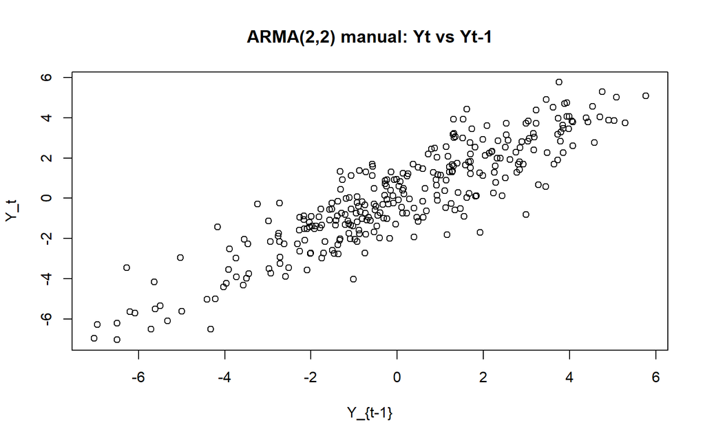

```r
yt_a_manual   <- arma22_manual[-1]
yt_1_a_manual <- arma22_manual[-length(arma22_manual)]
plot(y = yt_a_manual, x = yt_1_a_manual,
     main = "ARMA(2,2) manual: Yt vs Yt-1", xlab = "Y_{t-1}", ylab = "Y_t")
```

```r
cor(yt_a_manual, yt_1_a_manual)
```

```
## [1] 0.8955216
```

### Korelasi antara $Y_t$ dengan $Y_{t-2}$ Manual

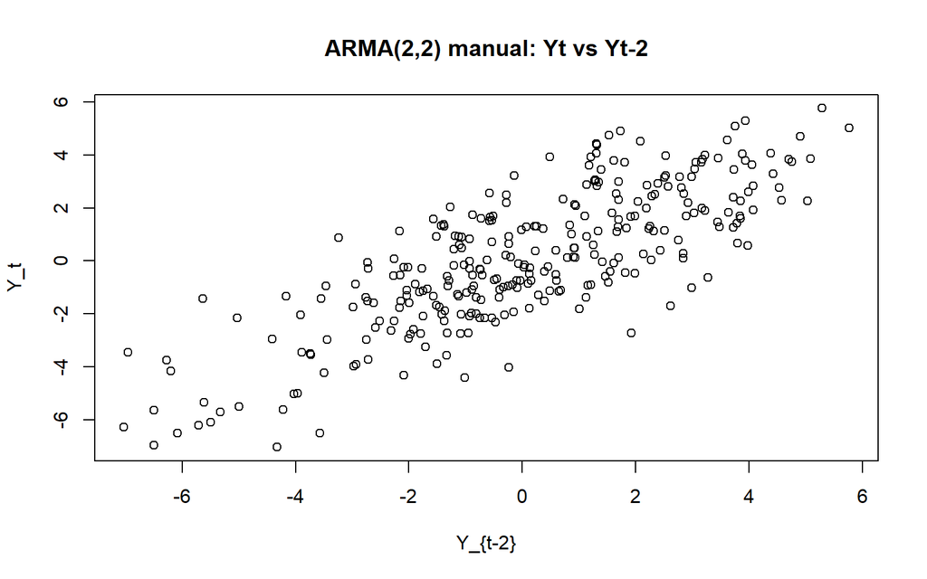

```r
yt_a2_manual  <- arma22_manual[-c(1,2)]
yt_2_a_manual <- arma22_manual[-c((length(arma22_manual)-1), length(arma22_manual))]
plot(y = yt_a2_manual, x = yt_2_a_manual,
     main = "ARMA(2,2) manual: Yt vs Yt-2", xlab = "Y_{t-2}", ylab = "Y_t")
```

```r
cor(yt_a2_manual, yt_2_a_manual)
```

```
## [1] 0.7899614
```